# Binary Classification Model for German Credit Risks Using R Take 2

David Lowe

September 14, 2018

Template Credit: Adapted from a template made available by Dr. Jason Brownlee of Machine Learning Mastery. [http://machinelearningmastery.com/]

SUMMARY: The purpose of this project is to construct a prediction model using various machine learning algorithms and to document the end-to-end steps using a template. The German Credit Risks Dataset is a binary-class classification situation where we are trying to predict one of the two possible outcomes.

INTRODUCTION: This dataset contains 1,000 entries with 20 categorial/symbolic attributes prepared by Prof. Hofmann. In this dataset, each entry represents a person who takes on credit risk by a German bank. Each person is classified as good or bad credit risks according to the set of attributes.

Because the case study also stipulated that it is worse to classify a customer as good when they are bad (weight of 5), than it is to classify a customer as bad when they are good (weight of 1). For this iteration, the script focuses on tuning various machine learning algorithms and identify the algorithm that can produce the best cost-and-accuracy tradeoffs.

From the cost vs accuracy comparison, both the Logistic Regression and AdaBoost achieved identical accuracy while keeping the costs of incorrect predictions low. Either algorithm should be considered for further modeling or production use.

Dataset Used: German Credit Data Set

Dataset ML Model: Binary classification with numerical and categorical attributes

Dataset Reference: https://archive.ics.uci.edu/ml/datasets/Statlog+%28German+Credit+Data%29

One potential source of performance benchmarks: https://www.kaggle.com/uciml/german-credit/home

The project aims to touch on the following areas:

1. Document a predictive modeling problem end-to-end.
2. Explore data cleaning and transformation options
3. Explore non-ensemble and ensemble algorithms for baseline model performance
4. Explore algorithm tuning techniques for improving model performance

Any predictive modeling machine learning project genrally can be broken down into about six major tasks:

1. Prepare Problem
2. Summarize Data
3. Prepare Data
4. Model and Evaluate Algorithms
5. Improve Accuracy or Results
6. Finalize Model and Present Results

## 1. Prepare Problem

### 1.a) Load libraries

```r
library(caret)
```

```r
library(corrplot)
library(ROCR)
```

### 1.b) Load dataset

```r
startTimeScript <- proc.time()
entireDataset <- read.table("german.data",
                            col.names=c("attr01","attr02","attr03","attr04","attr05","attr06","attr07","attr08","attr09","attr10","attr11","attr12","attr13","attr14","attr15","attr16","attr17","attr18","attr19","attr20","targetVar"))
# Re-label the class to "0" - Positive Class/Good Loan and "1" - Negative Class/Bad Loan
entireDataset$targetVar <- entireDataset$targetVar-1
entireDataset$targetVar <- as.factor(entireDataset$targetVar)
```

### 1.c) Set up key parameters to be used in the script

```r
# Create one random seed number for reproducible results
seedNum <- 888
set.seed(seedNum)

# Use variable totCol to hold the number of columns in the dataframe
totCol <- ncol(entireDataset)
```

## 2. Summarize Data

To gain a better understanding of the data that we have on-hand, we will leverage a number of descriptive statistics and data visualization techniques. The plan is to use the results to consider new questions, review assumptions, and validate hypotheses that we can investigate later with specialized models.

### 2.a) Descriptive statistics

#### 2.a.i) Peek at the data itself.

```r
head(entireDataset)
```

```
##   attr01 attr02 attr03 attr04 attr05 attr06 attr07 attr08 attr09 attr10
## 1    A11      6    A34    A43   1169    A65    A75      4    A93   A101
## 2    A12     48    A32    A43   5951    A61    A73      2    A92   A101
## 3    A14     12    A34    A46   2096    A61    A74      2    A93   A101
## 4    A11     42    A32    A42   7882    A61    A74      2    A93   A103
## 5    A11     24    A33    A40   4870    A61    A73      3    A93   A101
## 6    A14     36    A32    A46   9055    A65    A73      2    A93   A101
##   attr11 attr12 attr13 attr14 attr15 attr16 attr17 attr18 attr19 attr20
## 1      4   A121     67   A143   A152      2   A173      1   A192   A201
## 2      2   A121     22   A143   A152      1   A173      1   A191   A201
## 3      3   A121     49   A143   A152      1   A172      2   A191   A201
## 4      4   A122     45   A143   A153      1   A173      2   A191   A201
## 5      4   A124     53   A143   A153      2   A173      2   A191   A201
## 6      4   A124     35   A143   A153      1   A172      2   A192   A201
##   targetVar
## 1         0
## 2         1
## 3         0
## 4         0
## 5         1
## 6         0
```

#### 2.a.ii) Dimensions of the dataset.

```r
dim(entireDataset)
```

```
## [1] 1000   21
```

#### 2.a.iii) Types of the attributes.

```r
sapply(entireDataset, class)
```

```
##    attr01    attr02    attr03    attr04    attr05    attr06    attr07
##  "factor" "integer"  "factor"  "factor" "integer"  "factor"  "factor"
##    attr08    attr09    attr10    attr11    attr12    attr13    attr14
## "integer"  "factor"  "factor" "integer"  "factor" "integer"  "factor"
##    attr15    attr16    attr17    attr18    attr19    attr20 targetVar
##  "factor" "integer"  "factor" "integer"  "factor"  "factor"  "factor"
```

#### 2.a.iv) Statistical summary of all attributes.

```r
summary(entireDataset)
```

```
##  attr01        attr02     attr03        attr04        attr05
##  A11:274   Min.   : 4.0   A30: 40   A43    :280   Min.   :  250
##  A12:269   1st Qu.:12.0   A31: 49   A40    :234   1st Qu.: 1366
##  A13: 63   Median :18.0   A32:530   A42    :181   Median : 2320
##  A14:394   Mean   :20.9   A33: 88   A41    :103   Mean   : 3271
##            3rd Qu.:24.0   A34:293   A49    : 97   3rd Qu.: 3972
##            Max.   :72.0             A46    : 50   Max.   :18424
##                                     (Other): 55
##  attr06    attr07        attr08      attr09     attr10        attr11
##  A61:603   A71: 62   Min.   :1.000   A91: 50   A101:907   Min.   :1.000
##  A62:103   A72:172   1st Qu.:2.000   A92:310   A102: 41   1st Qu.:2.000
##  A63: 63   A73:339   Median :3.000   A93:548   A103: 52   Median :3.000
##  A64: 48   A74:174   Mean   :2.973   A94: 92              Mean   :2.845
##  A65:183   A75:253   3rd Qu.:4.000                        3rd Qu.:4.000
##                      Max.   :4.000                        Max.   :4.000
##
##   attr12        attr13       attr14     attr15        attr16
##  A121:282   Min.   :19.00   A141:139   A151:179   Min.   :1.000
##  A122:232   1st Qu.:27.00   A142: 47   A152:713   1st Qu.:1.000
##  A123:332   Median :33.00   A143:814   A153:108   Median :1.000
##  A124:154   Mean   :35.55                         Mean   :1.407
##             3rd Qu.:42.00                         3rd Qu.:2.000
##             Max.   :75.00                         Max.   :4.000
##
##   attr17        attr18       attr19     attr20    targetVar
##  A171: 22   Min.   :1.000   A191:596   A201:963   0:700
##  A172:200   1st Qu.:1.000   A192:404   A202: 37   1:300
##  A173:630   Median :1.000
##  A174:148   Mean   :1.155
##             3rd Qu.:1.000
##             Max.   :2.000
##
```

#### 2.a.v) Summarize the levels of the class attribute.

```r
entireDataset_x <- entireDataset[,1:(totCol-1)]
entireDataset_y <- entireDataset[,totCol]
cbind(freq=table(entireDataset_y), percentage=prop.table(table(entireDataset_y))*100)
```

```
##   freq percentage
## 0  700         70
## 1  300         30
```

#### 2.a.vi) Count missing values.

```r
sapply(entireDataset, function(x) sum(is.na(x)))
```

```
##    attr01    attr02    attr03    attr04    attr05    attr06    attr07
##         0         0         0         0         0         0         0
##    attr08    attr09    attr10    attr11    attr12    attr13    attr14
##         0         0         0         0         0         0         0
##    attr15    attr16    attr17    attr18    attr19    attr20 targetVar
##         0         0         0         0         0         0         0
```

## 3. Prepare Data

Some dataset may require additional preparation activities that will best exposes the structure of the problem and the relationships between the input attributes and the output variable. Some data-prep tasks might include:

- Cleaning data by removing duplicates, marking missing values and even imputing missing values.
- Feature selection where redundant features may be removed.
- Data transforms where attributes are scaled or redistributed in order to best expose the structure of the problem later to learning algorithms.

### 3.a) Data Cleaning

```r
# Not applicable for this iteration of the project.

# Mark missing values
#invalid <- 0
#entireDataset$some_col[entireDataset$some_col==invalid] <- NA

# Impute missing values
#entireDataset$some_col <- with(entireDataset, impute(some_col, mean))
```

### 3.b) Feature Selection

```r
# Not applicable for this iteration of the project.
```

### 3.c) Data Transforms

```r
# Not applicable for this iteration of the project.
```

### 3.d) Split-out training and validation datasets

We create a training dataset (variable name “training”) and a validation dataset (variable name “validation”).

```r
# Create a list of the rows in the original dataset we can use for training
training_index <- createDataPartition(entireDataset$targetVar, p=0.70, list=FALSE)

# Use 70% of data to training and testing the models
training <- entireDataset[training_index,]

# Select the remaining 30% of the data for validation
validation <- entireDataset[-training_index,]
```

```r
proc.time()-startTimeScript
```

```
##    user  system elapsed
##    0.53    0.14    0.74
```

## 4. Model and Evaluate Algorithms

After the data-prep, we next work on finding a workable model by evaluating a subset of machine learning algorithms that are good at exploiting the structure of the training. The typical evaluation tasks include:

- Defining test options such as cross validation and the evaluation metric to use.
- Spot checking a suite of linear and nonlinear machine learning algorithms.
- Comparing the estimated accuracy of algorithms.

For this project, we will evaluate one linear, three non-linear, and four ensemble algorithms:

Linear Algorithm: Logistic Regression

Non-Linear Algorithms: Decision Trees (CART), k-Nearest Neighbors, and Support Vector Machine

Ensemble Algorithms: Bagged CART, Random Forest, Adaboost, and Stochastic Gradient Boosting

The random number seed is reset before each run to ensure that the evaluation of each algorithm is performed using the same data splits. It ensures the results are directly comparable.

### 4.a) Set test options and evaluation metric

```r
# Run algorithms using 10-fold cross validation
control <- trainControl(method="repeatedcv", number=10, repeats=3)
metricTarget <- "Accuracy"
```

### 4.b) Generate model and calculate costs - Logistic Regression

```r
# Logistic Regression (Classification)
startTimeModule <- proc.time()
set.seed(seedNum)
fit.glm <- train(targetVar~., data=training, method="glm", metric=metricTarget, trControl=control)
print(fit.glm)
```

```
## Generalized Linear Model
##
## 700 samples
##  20 predictor
##   2 classes: '0', '1'
##
## No pre-processing
## Resampling: Cross-Validated (10 fold, repeated 3 times)
## Summary of sample sizes: 630, 630, 630, 630, 630, 630, ...
## Resampling results:
##
##   Accuracy   Kappa
##   0.7395238  0.3471955
```

```r
predictions <- predict(fit.glm, newdata=validation)
cm_LR <- confusionMatrix(predictions, validation$targetVar)
cm_LR
```

```
## Confusion Matrix and Statistics
##
##           Reference
## Prediction   0   1
##          0 187  42
##          1  23  48
##
##                Accuracy : 0.7833
##                  95% CI : (0.7324, 0.8286)
##     No Information Rate : 0.7
##     P-Value [Acc > NIR] : 0.0007553
##
##                   Kappa : 0.451
##  Mcnemar's Test P-Value : 0.0255737
##
##             Sensitivity : 0.8905
##             Specificity : 0.5333
##          Pos Pred Value : 0.8166
##          Neg Pred Value : 0.6761
##              Prevalence : 0.7000
##          Detection Rate : 0.6233
##    Detection Prevalence : 0.7633
##       Balanced Accuracy : 0.7119
##
##        'Positive' Class : 0
##
```

```r
proc.time()-startTimeModule
```

```
##    user  system elapsed
##    1.49    0.08    1.64
```

### 4.c) Generate model and calculate costs - Decision Tree

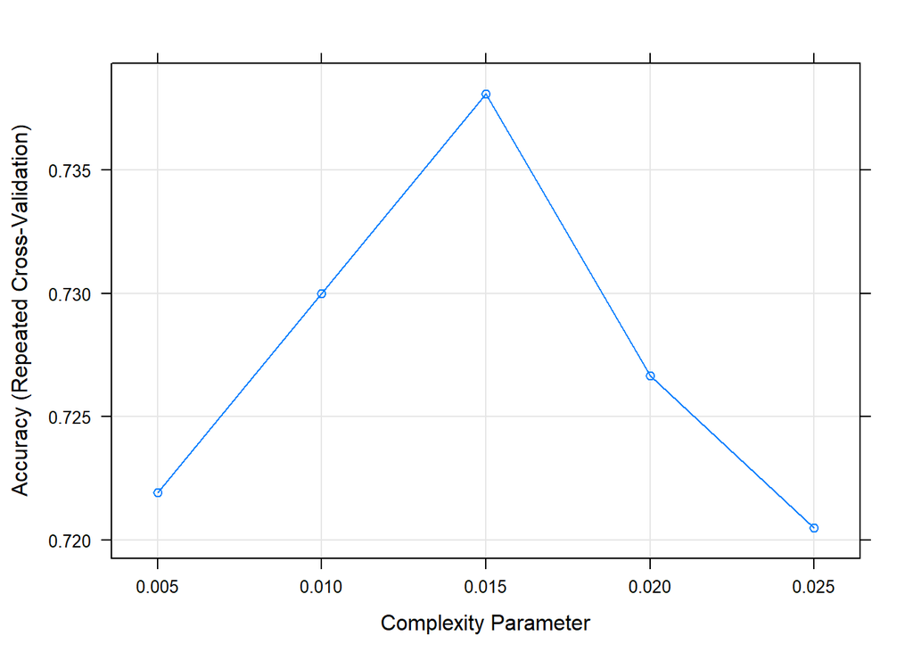

```r
# Decision Tree - CART (Regression/Classification)
startTimeModule <- proc.time()
set.seed(seedNum)
grid <- expand.grid(cp = c(0.005, 0.01, 0.015, 0.02, 0.025))
fit.cart <- train(targetVar~., data=training, method="rpart", metric=metricTarget, tuneGrid=grid, trControl=control)
#fit.cart <- train(targetVar~., data=training, method="rpart", metric=metricTarget, trControl=control)
plot(fit.cart)
```

```r
print(fit.cart)
```

```
## CART
##
## 700 samples
##  20 predictor
##   2 classes: '0', '1'
##
## No pre-processing
## Resampling: Cross-Validated (10 fold, repeated 3 times)
## Summary of sample sizes: 630, 630, 630, 630, 630, 630, ...
## Resampling results across tuning parameters:
##
##   cp     Accuracy   Kappa
##   0.005  0.7219048  0.3056287
##   0.010  0.7300000  0.3065001
##   0.015  0.7380952  0.3180062
##   0.020  0.7266667  0.2652343
##   0.025  0.7204762  0.2425963
##
## Accuracy was used to select the optimal model using the largest value.
## The final value used for the model was cp = 0.015.
```

```r
predictions <- predict(fit.cart, newdata=validation)
cm_CART <- confusionMatrix(predictions, validation$targetVar)
cm_CART
```

```
## Confusion Matrix and Statistics
##
##           Reference
## Prediction   0   1
##          0 183  63
##          1  27  27
##
##                Accuracy : 0.7
##                  95% CI : (0.6447, 0.7513)
##     No Information Rate : 0.7
##     P-Value [Acc > NIR] : 0.5284416
##
##                   Kappa : 0.1935
##  Mcnemar's Test P-Value : 0.0002249
##
##             Sensitivity : 0.8714
##             Specificity : 0.3000
##          Pos Pred Value : 0.7439
##          Neg Pred Value : 0.5000
##              Prevalence : 0.7000
##          Detection Rate : 0.6100
##    Detection Prevalence : 0.8200
##       Balanced Accuracy : 0.5857
##
##        'Positive' Class : 0
##
```

```r
proc.time()-startTimeModule
```

```
##    user  system elapsed
##    2.59    0.04    2.73
```

### 4.d) Generate model and calculate costs - k-Nearest Neighbors

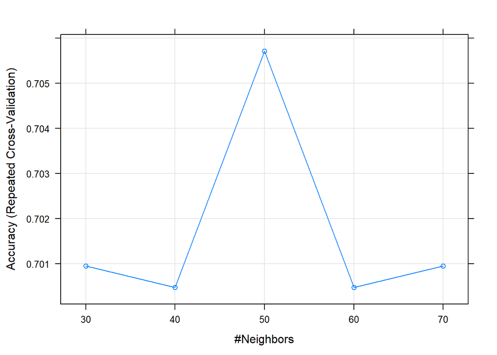

```r
# k-Nearest Neighbors (Regression/Classification)
startTimeModule <- proc.time()
set.seed(seedNum)
grid <- expand.grid(k = c(30, 40, 50, 60, 70))
fit.knn <- train(targetVar~., data=training, method="knn", metric=metricTarget, tuneGrid=grid, trControl=control)
plot(fit.knn)
```

```r
print(fit.knn)
```

```
## k-Nearest Neighbors
##
## 700 samples
##  20 predictor
##   2 classes: '0', '1'
##
## No pre-processing
## Resampling: Cross-Validated (10 fold, repeated 3 times)
## Summary of sample sizes: 630, 630, 630, 630, 630, 630, ...
## Resampling results across tuning parameters:
##
##   k   Accuracy   Kappa
##   30  0.7009524  0.041738162
##   40  0.7004762  0.019331404
##   50  0.7057143  0.032021698
##   60  0.7004762  0.003403927
##   70  0.7009524  0.004361371
##
## Accuracy was used to select the optimal model using the largest value.
## The final value used for the model was k = 50.
```

```r
predictions <- predict(fit.knn, newdata=validation)
cm_KNN <- confusionMatrix(predictions, validation$targetVar)
cm_KNN
```

```
## Confusion Matrix and Statistics
##
##           Reference
## Prediction   0   1
##          0 207  88
##          1   3   2
##
##                Accuracy : 0.6967
##                  95% CI : (0.6412, 0.7482)
##     No Information Rate : 0.7
##     P-Value [Acc > NIR] : 0.5781
##
##                   Kappa : 0.0109
##  Mcnemar's Test P-Value : <2e-16
##
##             Sensitivity : 0.98571
##             Specificity : 0.02222
##          Pos Pred Value : 0.70169
##          Neg Pred Value : 0.40000
##              Prevalence : 0.70000
##          Detection Rate : 0.69000
##    Detection Prevalence : 0.98333
##       Balanced Accuracy : 0.50397
##
##        'Positive' Class : 0
##
```

```r
proc.time()-startTimeModule
```

```
##    user  system elapsed
##    2.82    0.03    3.06
```

### 4.e) Generate model and calculate costs - Support Vector Machine

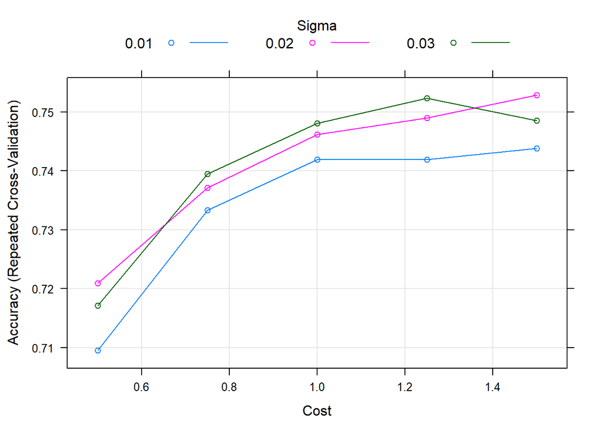

```r
# Support Vector Machine (Regression/Classification)
startTimeModule <- proc.time()
set.seed(seedNum)
grid <- expand.grid(sigma = c(0.01, 0.02, 0.03), C = c(0.5, 0.75, 1.0, 1.25, 1.5))
fit.svm <- train(targetVar~., data=training, method="svmRadial", metric=metricTarget, tuneGrid=grid, trControl=control)
plot(fit.svm)
```

```r
print(fit.svm)
```

```
## Support Vector Machines with Radial Basis Function Kernel
##
## 700 samples
##  20 predictor
##   2 classes: '0', '1'
##
## No pre-processing
## Resampling: Cross-Validated (10 fold, repeated 3 times)
## Summary of sample sizes: 630, 630, 630, 630, 630, 630, ...
## Resampling results across tuning parameters:
##
##   sigma  C     Accuracy   Kappa
##   0.01   0.50  0.7095238  0.04812941
##   0.01   0.75  0.7333333  0.19181857
##   0.01   1.00  0.7419048  0.25831720
##   0.01   1.25  0.7419048  0.27705100
##   0.01   1.50  0.7438095  0.29488681
##   0.02   0.50  0.7209524  0.10166661
##   0.02   0.75  0.7371429  0.22877498
##   0.02   1.00  0.7461905  0.29338259
##   0.02   1.25  0.7490476  0.31323444
##   0.02   1.50  0.7528571  0.33533964
##   0.03   0.50  0.7171429  0.07931914
##   0.03   0.75  0.7395238  0.22353550
##   0.03   1.00  0.7480952  0.29236394
##   0.03   1.25  0.7523810  0.31893774
##   0.03   1.50  0.7485714  0.32179483
##
## Accuracy was used to select the optimal model using the largest value.
## The final values used for the model were sigma = 0.02 and C = 1.5.
```

```r
predictions <- predict(fit.svm, newdata=validation)
cm_SVM <- confusionMatrix(predictions, validation$targetVar)
cm_SVM
```

```
## Confusion Matrix and Statistics
##
##           Reference
## Prediction   0   1
##          0 191  47
##          1  19  43
##
##                Accuracy : 0.78
##                  95% CI : (0.7288, 0.8256)
##     No Information Rate : 0.7
##     P-Value [Acc > NIR] : 0.001189
##
##                   Kappa : 0.4251
##  Mcnemar's Test P-Value : 0.000889
##
##             Sensitivity : 0.9095
##             Specificity : 0.4778
##          Pos Pred Value : 0.8025
##          Neg Pred Value : 0.6935
##              Prevalence : 0.7000
##          Detection Rate : 0.6367
##    Detection Prevalence : 0.7933
##       Balanced Accuracy : 0.6937
##
##        'Positive' Class : 0
##
```

```r
proc.time()-startTimeModule
```

```
##    user  system elapsed
##   44.34    0.66   48.85
```

### 4.f) Generate model and calculate costs - Bagged CART

```r
# Bagged CART (Regression/Classification)
startTimeModule <- proc.time()
set.seed(seedNum)
fit.bagcart <- train(targetVar~., data=training, method="treebag", metric=metricTarget, trControl=control)
print(fit.bagcart)
```

```
## Bagged CART
##
## 700 samples
##  20 predictor
##   2 classes: '0', '1'
##
## No pre-processing
## Resampling: Cross-Validated (10 fold, repeated 3 times)
## Summary of sample sizes: 630, 630, 630, 630, 630, 630, ...
## Resampling results:
##
##   Accuracy   Kappa
##   0.7285714  0.3218058
```

```r
predictions <- predict(fit.bagcart, newdata=validation)
cm_BAGCART <- confusionMatrix(predictions, validation$targetVar)
cm_BAGCART
```

```
## Confusion Matrix and Statistics
##
##           Reference
## Prediction   0   1
##          0 181  51
##          1  29  39
##
##                Accuracy : 0.7333
##                  95% CI : (0.6795, 0.7825)
##     No Information Rate : 0.7
##     P-Value [Acc > NIR] : 0.11490
##
##                   Kappa : 0.3174
##  Mcnemar's Test P-Value : 0.01888
##
##             Sensitivity : 0.8619
##             Specificity : 0.4333
##          Pos Pred Value : 0.7802
##          Neg Pred Value : 0.5735
##              Prevalence : 0.7000
##          Detection Rate : 0.6033
##    Detection Prevalence : 0.7733
##       Balanced Accuracy : 0.6476
##
##        'Positive' Class : 0
##
```

```r
proc.time()-startTimeModule
```

```
##    user  system elapsed
##   13.94    0.05   14.13
```

### 4.g) Generate model and calculate costs - Random Forest

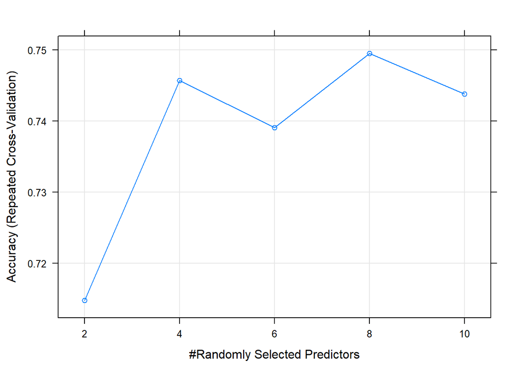

```r
# Random Forest (Regression/Classification)
startTimeModule <- proc.time()
set.seed(seedNum)
grid <- expand.grid(mtry = c(2, 4, 6, 8, 10))
fit.rf <- train(targetVar~., data=training, method="rf", metric=metricTarget, tuneGrid=grid, trControl=control)
plot(fit.rf)
```

```r
print(fit.rf)
```

```
## Random Forest
##
## 700 samples
##  20 predictor
##   2 classes: '0', '1'
##
## No pre-processing
## Resampling: Cross-Validated (10 fold, repeated 3 times)
## Summary of sample sizes: 630, 630, 630, 630, 630, 630, ...
## Resampling results across tuning parameters:
##
##   mtry  Accuracy   Kappa
##    2    0.7147619  0.06899979
##    4    0.7457143  0.26115653
##    6    0.7390476  0.26503927
##    8    0.7495238  0.30754863
##   10    0.7438095  0.29945290
##
## Accuracy was used to select the optimal model using the largest value.
## The final value used for the model was mtry = 8.
```

```r
predictions <- predict(fit.rf, newdata=validation)
cm_RF <- confusionMatrix(predictions, validation$targetVar)
cm_RF
```

```
## Confusion Matrix and Statistics
##
##           Reference
## Prediction   0   1
##          0 193  57
##          1  17  33
##
##                Accuracy : 0.7533
##                  95% CI : (0.7005, 0.8011)
##     No Information Rate : 0.7
##     P-Value [Acc > NIR] : 0.02388
##
##                   Kappa : 0.3273
##  Mcnemar's Test P-Value : 5.797e-06
##
##             Sensitivity : 0.9190
##             Specificity : 0.3667
##          Pos Pred Value : 0.7720
##          Neg Pred Value : 0.6600
##              Prevalence : 0.7000
##          Detection Rate : 0.6433
##    Detection Prevalence : 0.8333
##       Balanced Accuracy : 0.6429
##
##        'Positive' Class : 0
##
```

```r
proc.time()-startTimeModule
```

```
##    user  system elapsed
##  140.36    2.72  150.82
```

### 4.h) Generate model and calculate costs - AdaBoost

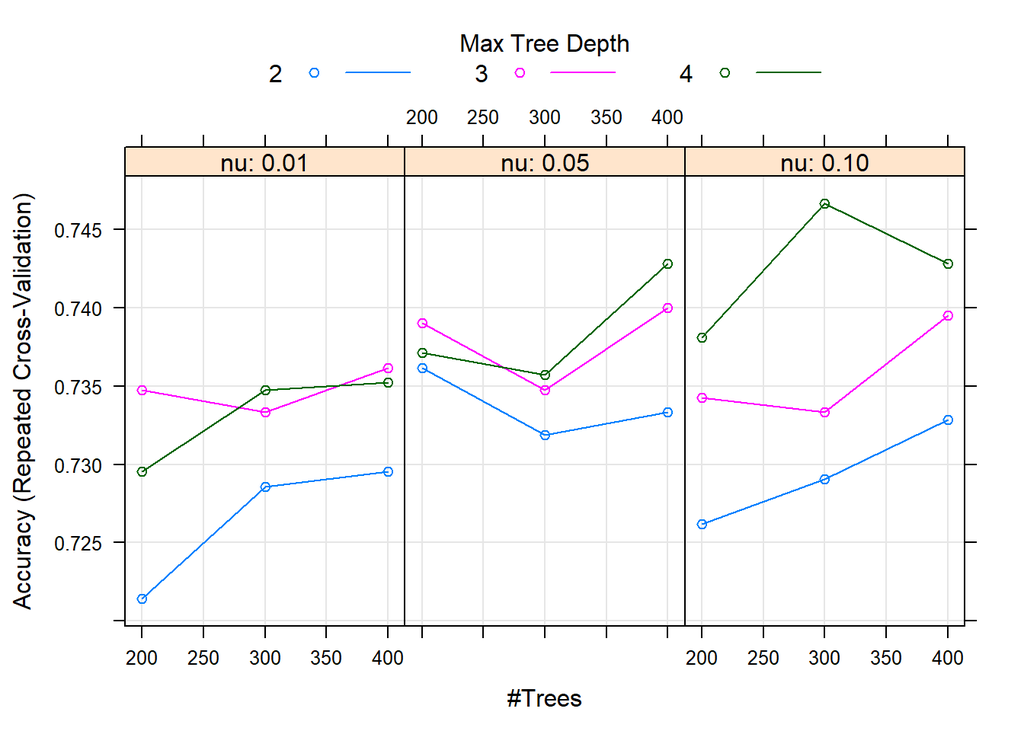

```r
# AdaBoost (Classification)
startTimeModule <- proc.time()
set.seed(seedNum)
grid <- expand.grid(iter=c(200, 300, 400), nu=c(0.01, 0.05, 0.1), maxdepth=c(2, 3, 4))
fit.ada <- train(targetVar~., data=training, method="ada", metric=metricTarget, tuneGrid=grid, trControl=control)
plot(fit.ada)
```

```r
print(fit.ada)
```

```
## Boosted Classification Trees
##
## 700 samples
##  20 predictor
##   2 classes: '0', '1'
##
## No pre-processing
## Resampling: Cross-Validated (10 fold, repeated 3 times)
## Summary of sample sizes: 630, 630, 630, 630, 630, 630, ...
## Resampling results across tuning parameters:
##
##   nu    maxdepth  iter  Accuracy   Kappa
##   0.01  2         200   0.7214286  0.1772737
##   0.01  2         300   0.7285714  0.1983167
##   0.01  2         400   0.7295238  0.2060576
##   0.01  3         200   0.7347619  0.2370158
##   0.01  3         300   0.7333333  0.2452122
##   0.01  3         400   0.7361905  0.2630659
##   0.01  4         200   0.7295238  0.2510829
##   0.01  4         300   0.7347619  0.2802555
##   0.01  4         400   0.7352381  0.2856147
##   0.05  2         200   0.7361905  0.2631343
##   0.05  2         300   0.7319048  0.2685941
##   0.05  2         400   0.7333333  0.2830705
##   0.05  3         200   0.7390476  0.2988569
##   0.05  3         300   0.7347619  0.2998175
##   0.05  3         400   0.7400000  0.3258996
##   0.05  4         200   0.7371429  0.3150997
##   0.05  4         300   0.7357143  0.3157448
##   0.05  4         400   0.7428571  0.3412514
##   0.10  2         200   0.7261905  0.2653926
##   0.10  2         300   0.7290476  0.2831255
##   0.10  2         400   0.7328571  0.3047394
##   0.10  3         200   0.7342857  0.3078103
##   0.10  3         300   0.7333333  0.3096117
##   0.10  3         400   0.7395238  0.3355866
##   0.10  4         200   0.7380952  0.3314646
##   0.10  4         300   0.7466667  0.3548460
##   0.10  4         400   0.7428571  0.3412843
##
## Accuracy was used to select the optimal model using the largest value.
## The final values used for the model were iter = 300, maxdepth = 4 and nu
##  = 0.1.
```

```r
predictions <- predict(fit.ada, newdata=validation)
cm_ADA <- confusionMatrix(predictions, validation$targetVar)
cm_ADA
```

```
## Confusion Matrix and Statistics
##
##           Reference
## Prediction   0   1
##          0 189  44
##          1  21  46
##
##                Accuracy : 0.7833
##                  95% CI : (0.7324, 0.8286)
##     No Information Rate : 0.7
##     P-Value [Acc > NIR] : 0.0007553
##
##                   Kappa : 0.4435
##  Mcnemar's Test P-Value : 0.0063572
##
##             Sensitivity : 0.9000
##             Specificity : 0.5111
##          Pos Pred Value : 0.8112
##          Neg Pred Value : 0.6866
##              Prevalence : 0.7000
##          Detection Rate : 0.6300
##    Detection Prevalence : 0.7767
##       Balanced Accuracy : 0.7056
##
##        'Positive' Class : 0
##
```

```r
proc.time()-startTimeModule
```

```
##    user  system elapsed
## 2627.15    3.86 2760.47
```

### 4.i) Generate model and calculate costs - Stochastic Gradient Boosting

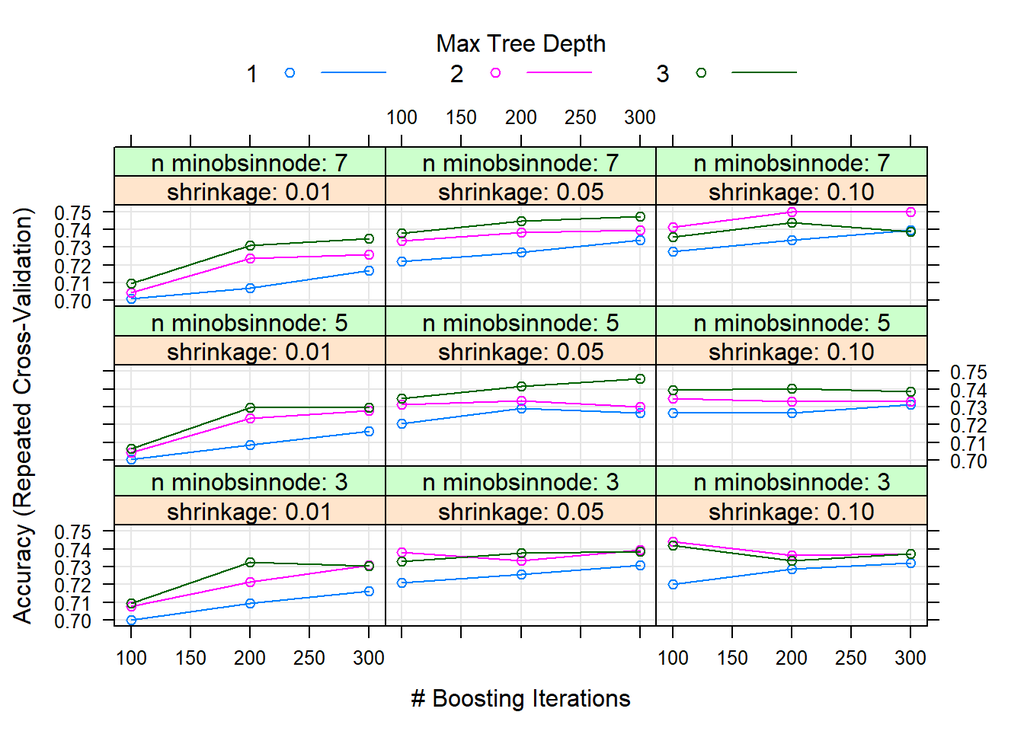

```r
# Stochastic Gradient Boosting (Regression/Classification)
startTimeModule <- proc.time()
set.seed(seedNum)
grid <- expand.grid(.n.trees=c(100, 200, 300), .shrinkage=c(0.01, 0.05, 0.1), .interaction.depth=c(1, 2, 3), .n.minobsinnode=c(3, 5, 7))
fit.gbm <- train(targetVar~., data=training, method="gbm", metric=metricTarget, tuneGrid=grid, trControl=control, verbose=F)
plot(fit.gbm)
```

```r
print(fit.gbm)
```

```
## Stochastic Gradient Boosting
##
## 700 samples
##  20 predictor
##   2 classes: '0', '1'
##
## No pre-processing
## Resampling: Cross-Validated (10 fold, repeated 3 times)
## Summary of sample sizes: 630, 630, 630, 630, 630, 630, ...
## Resampling results across tuning parameters:
##
##   shrinkage  interaction.depth  n.minobsinnode  n.trees  Accuracy
##   0.01       1                  3               100      0.7000000
##   0.01       1                  3               200      0.7095238
##   0.01       1                  3               300      0.7161905
##   0.01       1                  5               100      0.7004762
##   0.01       1                  5               200      0.7085714
##   0.01       1                  5               300      0.7161905
##   0.01       1                  7               100      0.7009524
##   0.01       1                  7               200      0.7071429
##   0.01       1                  7               300      0.7166667
##   0.01       2                  3               100      0.7076190
##   0.01       2                  3               200      0.7214286
##   0.01       2                  3               300      0.7309524
##   0.01       2                  5               100      0.7042857
##   0.01       2                  5               200      0.7238095
##   0.01       2                  5               300      0.7280952
##   0.01       2                  7               100      0.7042857
##   0.01       2                  7               200      0.7238095
##   0.01       2                  7               300      0.7257143
##   0.01       3                  3               100      0.7095238
##   0.01       3                  3               200      0.7323810
##   0.01       3                  3               300      0.7304762
##   0.01       3                  5               100      0.7066667
##   0.01       3                  5               200      0.7295238
##   0.01       3                  5               300      0.7295238
##   0.01       3                  7               100      0.7095238
##   0.01       3                  7               200      0.7309524
##   0.01       3                  7               300      0.7347619
##   0.05       1                  3               100      0.7209524
```

[output cut: 124 more lines]

```
##   0.355148553
##   0.368629531
##   0.323581008
##   0.318681418
##   0.331333264
##   0.319757675
##   0.341049848
##   0.340174997
##   0.311749374
##   0.348976980
##   0.334429003
##
## Accuracy was used to select the optimal model using the largest value.
## The final values used for the model were n.trees = 200,
##  interaction.depth = 2, shrinkage = 0.1 and n.minobsinnode = 7.
```

```r
predictions <- predict(fit.gbm, newdata=validation)
cm_GBM <- confusionMatrix(predictions, validation$targetVar)
cm_GBM
```

```
## Confusion Matrix and Statistics
##
##           Reference
## Prediction   0   1
##          0 187  50
##          1  23  40
##
##                Accuracy : 0.7567
##                  95% CI : (0.704, 0.8041)
##     No Information Rate : 0.7
##     P-Value [Acc > NIR] : 0.017412
##
##                   Kappa : 0.3663
##  Mcnemar's Test P-Value : 0.002342
##
##             Sensitivity : 0.8905
##             Specificity : 0.4444
##          Pos Pred Value : 0.7890
##          Neg Pred Value : 0.6349
##              Prevalence : 0.7000
##          Detection Rate : 0.6233
##    Detection Prevalence : 0.7900
##       Balanced Accuracy : 0.6675
##
##        'Positive' Class : 0
##
```

```r
proc.time()-startTimeModule
```

```
##    user  system elapsed
##  225.23    0.44  232.88
```

## 5. Model Comparisons

### 5.a) Compare the accuracy of models

```r
results <- resamples(list(LR=fit.glm, CART=fit.cart, kNN=fit.knn, SVM=fit.svm, BagCART=fit.bagcart, RF=fit.rf, AdaBoost=fit.ada, GBM=fit.gbm))
summary(results)
```

```
##
## Call:
## summary.resamples(object = results)
##
## Models: LR, CART, kNN, SVM, BagCART, RF, AdaBoost, GBM
## Number of resamples: 30
##
## Accuracy
##               Min.   1st Qu.    Median      Mean   3rd Qu.      Max. NA's
## LR       0.5857143 0.7285714 0.7571429 0.7395238 0.7678571 0.8142857    0
## CART     0.6000000 0.7142857 0.7428571 0.7380952 0.7714286 0.8142857    0
## kNN      0.6857143 0.7000000 0.7000000 0.7057143 0.7142857 0.7285714    0
## SVM      0.6857143 0.7321429 0.7571429 0.7528571 0.7821429 0.8428571    0
## BagCART  0.6142857 0.7035714 0.7285714 0.7285714 0.7571429 0.8428571    0
## RF       0.6714286 0.7285714 0.7428571 0.7495238 0.7714286 0.8000000    0
## AdaBoost 0.6714286 0.6928571 0.7428571 0.7466667 0.7857143 0.8571429    0
## GBM      0.6571429 0.7178571 0.7428571 0.7500000 0.7714286 0.8428571    0
##
## Kappa
##                 Min.   1st Qu.    Median      Mean    3rd Qu.      Max.
## LR        0.05228758 0.2909281 0.3616592 0.3471955 0.41379310 0.5255474
## CART      0.04761905 0.2448148 0.3164885 0.3180062 0.40249433 0.5255474
## kNN      -0.02803738 0.0000000 0.0000000 0.0320217 0.06542056 0.1284404
## SVM       0.18518519 0.2886659 0.3468016 0.3353396 0.40000000 0.5600000
## BagCART   0.06896552 0.2634100 0.3229845 0.3218058 0.37732888 0.6099291
## RF        0.10852713 0.2400000 0.2944296 0.3075486 0.37764365 0.4656489
## AdaBoost  0.10852713 0.2370324 0.3567101 0.3548460 0.45255474 0.6402878
## GBM       0.20529801 0.2635659 0.3336632 0.3551486 0.41128173 0.5864662
##          NA's
## LR          0
## CART        0
## kNN         0
## SVM         0
## BagCART     0
## RF          0
## AdaBoost    0
## GBM         0
```

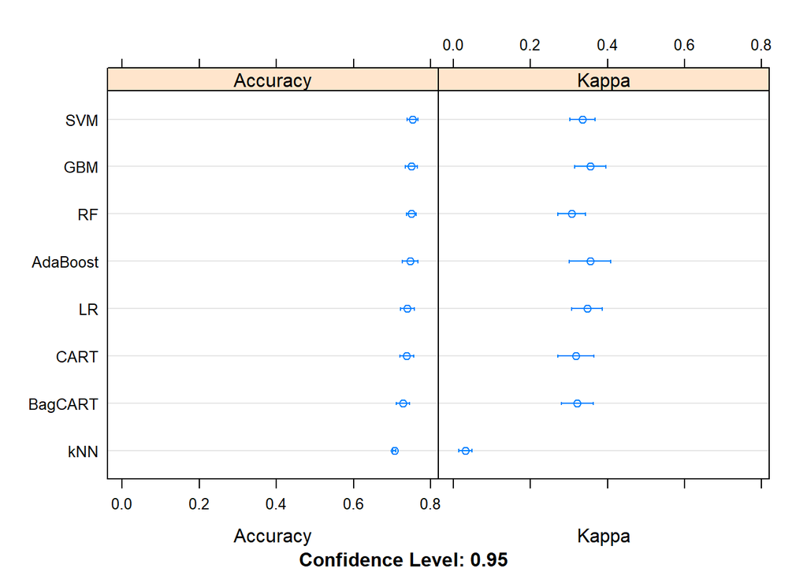

```r
dotplot(results)
```

### 5.a) Compare the cost of models

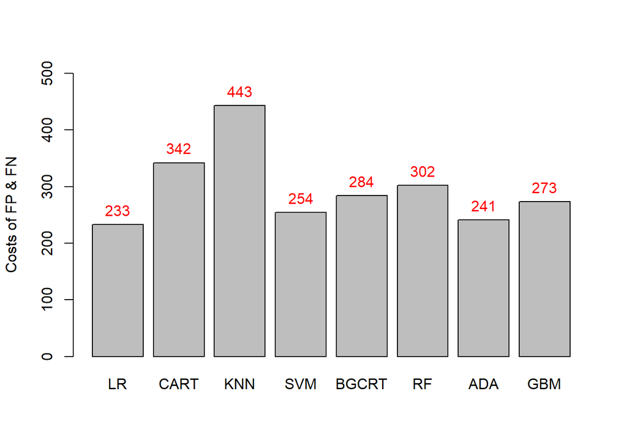

```r
# Calculate the costs of wrong predictions
# Weight of 1 for false negative and weight of 5 for false positive
weight_fn <- 1
weight_fp <- 5
cost_LR <- (cm_LR$table[1,2]*weight_fp) + (cm_LR$table[2,1]*weight_fn)
cost_CART <- (cm_CART$table[1,2]*weight_fp) + (cm_CART$table[2,1]*weight_fn)
cost_KNN <- (cm_KNN$table[1,2]*weight_fp) + (cm_KNN$table[2,1]*weight_fn)
cost_SVM <- (cm_SVM$table[1,2]*weight_fp) + (cm_SVM$table[2,1]*weight_fn)
cost_BAGCART <- (cm_BAGCART$table[1,2]*weight_fp) + (cm_BAGCART$table[2,1]*weight_fn)
cost_RF <- (cm_RF$table[1,2]*weight_fp) + (cm_RF$table[2,1]*weight_fn)
cost_ADA <- (cm_ADA$table[1,2]*weight_fp) + (cm_ADA$table[2,1]*weight_fn)
cost_GBM <- (cm_GBM$table[1,2]*weight_fp) + (cm_GBM$table[2,1]*weight_fn)
costs <- c(cost_LR, cost_CART, cost_KNN, cost_SVM, cost_BAGCART, cost_RF, cost_ADA, cost_GBM)
models <- c("LR", "CART", "KNN", "SVM", "BGCRT", "RF", "ADA", "GBM")
costs_compare <- data.frame(costs, models)
plot_original <- barplot(costs_compare[,1], names.arg=costs_compare[,2], ylab = "Costs of FP & FN", ylim = range(0,500))
text(x=plot_original, y=costs_compare[,1], label=costs_compare[,1], pos=3, col="red")
```

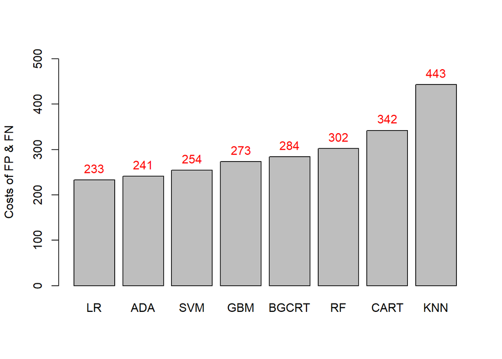

```r
costs_sorted <- costs_compare[order(costs_compare[,1], decreasing = FALSE),]
plot_sorted <- barplot(costs_sorted[,1], names.arg=costs_sorted[,2], ylab = "Costs of FP & FN", ylim = range(0,500))
text(x=plot_sorted, y=costs_sorted[,1], label=costs_sorted[,1], pos=3, col="red")
```

### 5.c) Plot the cost vs. accuracy of models

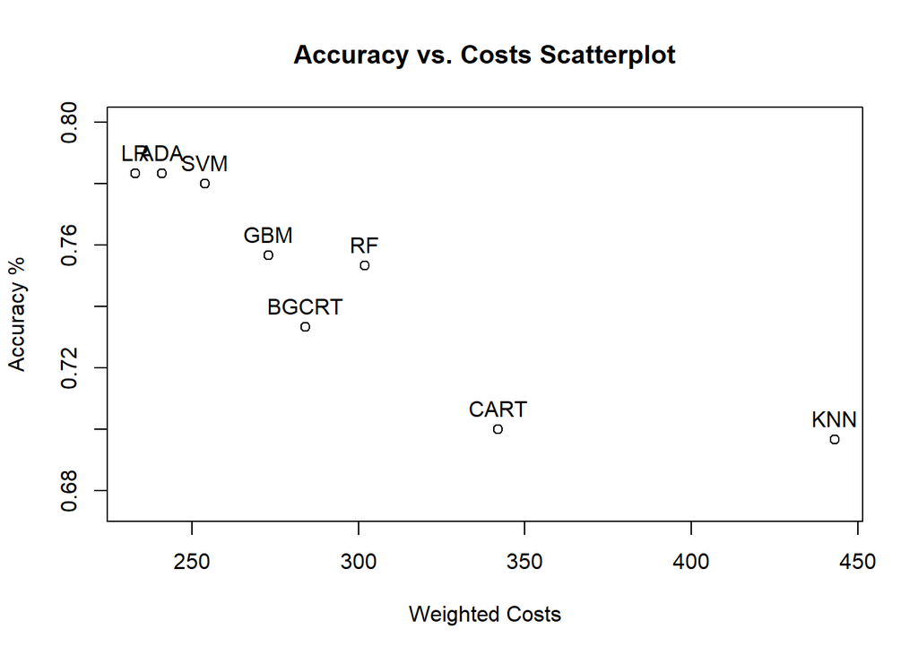

```r
accuracy_LR <- cm_LR$overall[['Accuracy']]
accuracy_CART <- cm_CART$overall[['Accuracy']]
accuracy_KNN <- cm_KNN$overall[['Accuracy']]
accuracy_SVM <- cm_SVM$overall[['Accuracy']]
accuracy_BAGCART <- cm_BAGCART$overall[['Accuracy']]
accuracy_RF <- cm_RF$overall[['Accuracy']]
accuracy_ADA <- cm_ADA$overall[['Accuracy']]
accuracy_GBM <- cm_GBM$overall[['Accuracy']]
ratios <- c(accuracy_LR,accuracy_CART,accuracy_KNN,accuracy_SVM,accuracy_BAGCART,accuracy_RF,accuracy_ADA,accuracy_GBM)
costs_ratios <- data.frame(costs, ratios, models)
plot_vs <- plot(costs_ratios[,1], costs_ratios[,2], main="Accuracy vs. Costs Scatterplot", xlab="Weighted Costs", ylab="Accuracy %", ylim=range(0.675,0.8))
text(x=costs_ratios[,1], y=costs_ratios[,2], labels=costs_ratios[,3], pos=3)
```

```r
proc.time()-startTimeScript
```

```
##    user  system elapsed
## 3059.59    8.31 3216.79
```